# jieba分词-简单商品评价分析

```python
import jieba
#1.导入包
import nltk
from nltk import FreqDist #统计词频
```

### jieba分词有三种模式

```
1.全模式cut，第二个参数cat_all=True
2.精确模式cut,第二个参数cat_all=Flae  默认
3.搜索引擎模式：cut_for_search函数
```

```python
tmpstr = "郭靖和哀牢山三十六剑。"
res = jieba.cut(tmpstr) # 精确模式

print(' '.join(res)) # 是一个可迭代的 generator，可以使用 for 循环来遍历结果，本质上类似list
```

```
Building prefix dict from the default dictionary ...
Dumping model to file cache C:\Users\admin\AppData\Local\Temp\jieba.cache
Loading model cost 0.631 seconds.
Prefix dict has been built successfully.
```

```
郭靖 和 哀牢山 三十六 剑 。
```

```python
tmpstr = "郭靖和哀牢山三十六剑。"
res = jieba.cut(tmpstr,cut_all=True) # 全模式

print(' '.join(res)) # 是一个可迭代的 generator，可以使用 for 循环来遍历结果，本质上类似list
```

```
郭 靖 和 哀牢山 三十 三十六 十六 剑 。
```

```python
res = jieba.cut_for_search(tmpstr) # 搜索引擎模式

print('/ '.join(res)) # 是一个可迭代的 generator，可以使用 for 循环来遍历结果，本质上类似list
```

```
郭靖/ 和/ 哀牢山/ 三十/ 十六/ 三十六/ 剑/ 。
```

修改词典 动态增删新词 在程序中可以动态根据分词的结果，对内存中的词库进行更新 add_word(word)

word：新词 freq=None：词频 tag=None：具体词性

del_word(word)

```python
# 动态修改词典
jieba.add_word("哀牢山三十六剑")
'/'.join(jieba.cut(tmpstr))
```

```
'郭靖/和/哀牢山三十六剑/。'
```

```python
jieba.del_word("哀牢山三十六剑")
'/'.join(jieba.cut(tmpstr))
```

```
'郭靖/和/哀牢山/三十六/剑/。'
```

使用自定义词典 load_userdict(file_name)

file_name：文件类对象或自定义词典的路径

词典基本格式

一个词占一行：词、词频（可省略）、词性（可省略），用空格隔开 词典文件必须为 UTF-8 编码 必要时可以使用Uedit32进行文件编码转换 云计算 5

李小福 2 nr

easy_install 3 eng

台中

```python
dict = '金庸小说词库.txt'
jieba.load_userdict(dict) # dict为自定义词典的路径
''.join(jieba.cut(tmpstr))
```

[output not shown]

使用搜狗细胞词库 https://pinyin.sogou.com/dict/

按照词库分类或者关键词搜索方式，查找并下载所需词库

使用转换工具，将其转换为txt格式

深蓝词库转换 奥创词库转换

在程序中导入相应词库

## 去除停用词

```
常见的停用词种类
超高频的常用词：基本不携带有效信息/歧义太多无分析价值

的、地、得
虚词：如介词，连词等

只、条、件
当、从、同
专业领域的高频词：基本不携带有效信息

视情况而定的停用词

呵呵
emoj
```

## 分词后去除停用词

### 基本步骤

```
1. 读入停用词表文件
2. 正常分词
3. 在分词结果中去除停用词
```

新列表 = [ word for word in 源列表 if word not in 停用词列表 ]

该方法存在的问题：停用词必须要被分词过程正确拆分出来才行

词性标注 import jieba.posseg

posseg.cut()：给出附加词性的分词结果

词性标注采用和 ICTCLAS 兼容的标记法

后续可基于词性做进一步处理，如只提取出名词，动词等

```python
import jieba.posseg
```

```python
tmpstr = "郭靖和哀牢山三十六剑。"
psg=jieba.posseg.cut(tmpstr)
for item in psg:
    print(item.word,item.flag)
```

```
郭靖 x
和 c
哀牢山三十六剑 x
。 x
```

## 分词的NLTK实现

```
NLTK只能识别用空格作为词条分割方式，因此不能直接用于中文文本的分词。

一般的做法是先用jieba分词，然后转换为空格分隔的连续文本，再转入NLTK框架使用。

rawtext = '周伯通笑道：“你懂了吗？...”
txt = ' '.join(jieba.cut(rawtext)) # "周伯通 笑 道 ：..."
toke = nltk.word_tokenize(txt) # ['周伯通', '笑', '道', '：'...]
```

## 案例简单的商品评价分析词云图

### 1.导入库和数据文件

```python
import pandas as pd
```

```python
file_data=pd.read_csv('comment.csv',encoding='GBK')
file_data
```

|  | 评价信息 |
| --- | --- |
| 0 | :"再买，半价，很优?惠。收到货了，包装很好，看起来很高档，东西质量没得说，很不错，这个价格... |
| 1 | :"挺好吃的⊙▽⊙，好评，买给老弟的，，老弟说很喜欢，必须好评，一直支持这家店，官方旗舰店嘛... |
| 2 | :"首先表扬店家的客服，至始至终都很热情专业，满分好评！发货速度非常快，隔天就收到货了，东西... |
| 3 | "满满一大箱呢！物流超快，昨晚买的，今天就到了！超赞超赞！价格很划算，总吃坚果什么的也腻了，... |
| 4 | "宝贝已收到，物美价廉，收到的时候发现和图片描述的一样，超级划算！值得再次光顾！美美滴，比实... |
| ... | ... |
| 716 | 不错东西挺多的 |
| 717 | 喜欢 很好 鼠呆呆 |
| 718 | 都好吃，好多东西 |
| 719 | 垃圾东西影都没看到不知道让快递送哪去了客服到现在还不回了辣鸡 |
| 720 | 喜欢 |

721 rows × 1 columns

```python
# 2.去重
file_data=file_data.drop_duplicates()
file_data
```

|  | 评价信息 |
| --- | --- |
| 0 | :"再买，半价，很优?惠。收到货了，包装很好，看起来很高档，东西质量没得说，很不错，这个价格... |
| 1 | :"挺好吃的⊙▽⊙，好评，买给老弟的，，老弟说很喜欢，必须好评，一直支持这家店，官方旗舰店嘛... |
| 2 | :"首先表扬店家的客服，至始至终都很热情专业，满分好评！发货速度非常快，隔天就收到货了，东西... |
| 3 | "满满一大箱呢！物流超快，昨晚买的，今天就到了！超赞超赞！价格很划算，总吃坚果什么的也腻了，... |
| 4 | "宝贝已收到，物美价廉，收到的时候发现和图片描述的一样，超级划算！值得再次光顾！美美滴，比实... |
| ... | ... |
| 716 | 不错东西挺多的 |
| 717 | 喜欢 很好 鼠呆呆 |
| 718 | 都好吃，好多东西 |
| 719 | 垃圾东西影都没看到不知道让快递送哪去了客服到现在还不回了辣鸡 |
| 720 | 喜欢 |

537 rows × 1 columns

```python
file_data.info()
```

```
<class 'pandas.core.frame.DataFrame'>
Int64Index: 537 entries, 0 to 720
Data columns (total 1 columns):
 #   Column  Non-Null Count  Dtype
---  ------  --------------  -----
 0   评价信息    537 non-null    object
dtypes: object(1)
memory usage: 8.4+ KB
```

```python
#3. 分词，jieba分词，精确模式
cut_words=jieba.lcut(str(file_data['评价信息'].values),cut_all=False)
cut_words
```

```
['[',
 "'",
 ':',
 '"',
 '再',
 '买',
 '，',
 '半价',
 '，',
 '很优',
 '?',
 '惠',
 '。',
 '收到',
 '货',
 '了',
 '，',
 '包装',
 '很',
 '好',
 '，',
 '看起来',
 '很',
 '高档',
 '，',
 '东西',
 '质量',
 '没得说',
 '，',
 '很',
 '不错',
 '，',
 '这个',
 '价格',
 '买到',
 '比',
 '我',
 '预期',
 '的',
 '质量',
```

[output cut: 946 more lines]

```
 '的',
 '味道',
 '杠杠',
 '滴',
 '，',
 '我',
 '儿子',
 '说',
 '好吃',
 '非常',
 '好吃',
 '，',
 '女友',
 '很',
 ...]
```

```python
#4. 加载停用词表，并在评价中去掉停用词
with open('./stoplist.txt') as f:
    #打开停用词文件，读取里面的词
    stop_words=f.read()
    new_data=[]
    for word in cut_words :
        if word not in stop_words:

            new_data.append(word)
new_data
```

```
['买',
 '半价',
 '很优',
 '惠',
 '收到',
 '货',
 '包装',
 '高档',
 '东西',
 '质量',
 '没得说',
 '不错',
 '价格',
 '买到',
 '预期',
 '质量',
 '好太多',
 '产品描述',
 '实物',
 '一致',
 '满意',
 '性价比',
 '划算',
 '便宜',
 '实惠',
 '赞',
 '快递',
 '很快',
 '不错',
 '卖家',
 '发货',
 '速度',
 '更是',
 '神速',
 '卖家',
 '服务态度',
 '推荐',
 '朋友',
 '买',
 '4.6',
```

[output cut: 946 more lines]

```
 '东西',
 '一起',
 '分享',
 '值不值得',
 '点开',
 '知道',
 '质量',
 '划算',
 '抱',
 '试一试',
 '心态',
 '买',
 '关键',
 '包邮',
 ...]
```

```python
# 5.词频统计
#1.导入包
#import nltk
#from nltk import FreqDist #统计词频
freq_list= FreqDist(new_data)
#取出高频词
most_common_words=freq_list.most_common()
most_common_words
```

```
[('喜欢', 260),
 ('买', 210),
 ('不错', 208),
 ('鼠', 183),
 ('东西', 138),
 ('好吃', 131),
 ('客服', 123),
 ('满意', 106),
 ('朋友', 98),
 ('零食', 89),
 ('吃', 88),
 ('好评', 86),
 ('松鼠', 79),
 ('收到', 78),
 ('服务', 78),
 ('挺', 74),
 ('味道', 71),
 ('包装', 67),
 ('物流', 66),
 ('女朋友', 63),
 ('质量', 61),
 ('送', 61),
 ('服务态度', 60),
 ('真的', 54),
 ('下次', 53),
 ('很快', 52),
 ('三只', 51),
 ('超级', 50),
 ('特别', 47),
 ('快递', 41),
 ('卖家', 37),
 ('便宜', 36),
 ('价格', 34),
 ('送给', 33),
 ('划算', 32),
 ('态度', 32),
 ('开心', 31),
 ('一直', 30),
 ('购物', 29),
 ('妹妹', 29),
```

[output cut: 946 more lines]

```
 ('家乡', 1),
 ('企业', 1),
 ('减肥', 1),
 ('╭', 1),
 ('╮', 1),
 ('极快', 1),
 ('店买', 1),
 ('齐全', 1),
 ('独立', 1),
 ('辣辣的', 1),
 ('香香的', 1),
 ('停不下来', 1),
 ('洋送', 1),
 ('朋', 1),
 ...]
```

```python
#6.制作词云图
#1）导包
from wordcloud import WordCloud
from matplotlib import pyplot as plt
```

```python
#2）实例化词云类对象，并加载数据
wc=WordCloud(font_path='C:\Windows\Fonts\SIMLI.TTF',background_color='white',width=1000, height=800 ).generate( ' '.join(new_data))
```

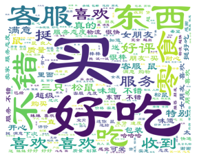

```python
#用plt显示图片
plt.imshow(wc)
plt.axis('off')#不显示坐标轴
plt.show()
```